#### This Python notebook describes several statistical tests and concepts, presented in alphabetical order.

```python
# Import modules
import numpy as np
import pandas as pd
import seaborn as sns
import warnings
import random
import matplotlib.pyplot as plt
warnings.filterwarnings('ignore')
```

# Anderson Darling Normality Test

This test determines if a data set is normally distributed.

```python
from scipy.stats import anderson

normally_distibuted_data = np.random.normal(size=1000)

anderson_result = anderson(normally_distibuted_data)

significance_level, critical_value = anderson_result.significance_level[2], anderson_result.critical_values[2]
if anderson_result.statistic < critical_value:
   print('Data follows normal distribution (p ≤ 0.05).')
else:
   print('Data does not follows normal distribution')
print("The statistic is: "  + str(anderson_result.statistic))
```

```
Data follows normal distribution (p ≤ 0.05).
The statistic is: 0.40207214374413525
```

# ANOVA (and Tukey)

## Independent one way

The ANOVA is used to determine whether there are any statistically significant differences between the means of three or more independent groups. The Tukey test is used to determine where the differences lie.

```python
from scipy.stats import f_oneway # for ANOVA
from statsmodels.stats.multicomp import pairwise_tukeyhsd # for Tukey test

# Create data
df = pd.DataFrame({'score': [85, 86, 88, 75, 78, 94, 98, 79, 71, 80, # group a
                             91, 92, 93, 90, 97, 94, 82, 88, 95, 96, # group b
                             79, 78, 88, 94, 92, 85, 83, 85, 82, 81], # group c
                   'group': np.repeat(['a', 'b', 'c'], repeats=10)})

a = df.score[df.group == 'a'].tolist()
b = df.score[df.group == 'b'].tolist()
c = df.score[df.group == 'c'].tolist()

# Perform ANOVA
statistic, pvalue = f_oneway(a, b, c)
if pvalue >= 0.05:
    print("There is no significant difference between the means.")
else:
    print("There is a significant difference between the means.")
print("The statistic is: " + str(statistic) + ", the p-value is: " + str(pvalue) + "\n")

# Perform Tukey's test
tukey = pairwise_tukeyhsd(endog=df['score'], groups=df['group'], alpha=0.05)
print(tukey)
```

```
There is a significant difference between the means.
The statistic is: 5.167774552944481, the p-value is: 0.012582197136592609

 Multiple Comparison of Means - Tukey HSD, FWER=0.05
=====================================================
group1 group2 meandiff p-adj   lower    upper  reject
-----------------------------------------------------
     a      b      8.4 0.0159   1.4259 15.3741   True
     a      c      1.3 0.8894  -5.6741  8.2741  False
     b      c     -7.1 0.0454 -14.0741 -0.1259   True
-----------------------------------------------------
```

## Independent two way

This test compares the mean differences between groups that have been split on two independent variables (factors). This test determines if there is an interaction between the two independent variables on the dependent variable.

```python
import statsmodels.api as sm
from statsmodels.formula.api import ols

# Create data
df = pd.DataFrame({'water': np.repeat(['daily', 'weekly'], 15),
                   'sun': np.tile(np.repeat(['low', 'med', 'high'], 5), 2),
                   'height': [6, 6, 6, 5, 6, 5, 5, 6, 4, 5,
                              6, 6, 7, 8, 7, 3, 4, 4, 4, 5,
                              4, 4, 4, 4, 4, 5, 6, 6, 7, 8]})
# Perform ANOVA
model = ols('height ~ C(water) + C(sun) + C(water):C(sun)', data=df).fit()
print(sm.stats.anova_lm(model, typ=2))
```

```
                    sum_sq    df        F    PR(>F)
C(water)          8.533333   1.0  16.0000  0.000527
C(sun)           24.866667   2.0  23.3125  0.000002
C(water):C(sun)   2.466667   2.0   2.3125  0.120667
Residual         12.800000  24.0      NaN       NaN
```

This test is used to compare three or more group means where the participants are the same in each group.

```python
import statsmodels.api as sm
from statsmodels.stats.anova import AnovaRM

# Create data
data = {
    'subject': ['S1'] * 6 + ['S2'] * 6 + ['S3'] * 6,
    'time': ['T1', 'T2', 'T3'] * 6,
    'condition': ['C1', 'C1', 'C1', 'C2', 'C2', 'C2'] * 3,
    'performance': [
        0.1, 0.2, 0.3,  # subject 1, condition 1
        0.1, 0.2, 0.4,  # subject 1, condition 2
        0.3, 0.3, 0.4,  # subject 2, condition 1
        0.3, 0.4, 0.5,  # subject 2, condition 2
        0.5, 0.6, 0.7,  # subject 3, condition 1
        0.6, 0.6, 0.8   # subject 3, condition 2
    ]
}
df = pd.DataFrame(data)

# Perform ANOVA
aovrm = AnovaRM(df, 'performance', 'subject', within=['time', 'condition'])
res = aovrm.fit()
print(res.summary())
```

```
                   Anova
===========================================
               F Value Num DF Den DF Pr > F
-------------------------------------------
time           44.8000 2.0000 4.0000 0.0018
condition      25.0000 1.0000 2.0000 0.0377
time:condition  1.6000 2.0000 4.0000 0.3086
===========================================
```

# Augmented Dickey-Fuller Test

This test determines if a time series has stationarity (constant mean, variance, and covariance over time).

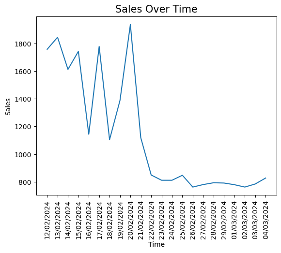

```python
# Create 2-column dataframe with 'Date' and 'Sales'
data = {'Date': ['12/02/2024', '13/02/2024', '14/02/2024', '15/02/2024', '16/02/2024', '17/02/2024', '18/02/2024', '19/02/2024', '20/02/2024', '21/02/2024', '22/02/2024', '23/02/2024', '24/02/2024', '25/02/2024', '26/02/2024', '27/02/2024', '28/02/2024', '29/02/2024', '01/03/2024', '02/03/2024', '03/03/2024', '04/03/2024'],
              'Sales': [1757, 1844, 1612, 1742, 1144, 1778, 1105, 1388, 1936, 1119, 850, 812, 812, 848, 763, 781, 794, 792, 780, 763, 785, 828]}
df = pd.DataFrame(data)

sns.lineplot(x=df['Date'], y=df['Sales'])
plt.title('Sales Over Time', size=15)
plt.xlabel('Time')
plt.ylabel('Sales')
plt.xticks(rotation=90);
```

```python
from statsmodels.tsa.stattools import adfuller

statistic, pvalue, lags, obs, crit, t = adfuller(df['Sales'])
if pvalue >= 0.05:
 print('Data does not exhibit stationarity.')
else:
 print('Data does exhibit stationarity.')
print("The statistic is: "  + str(statistic) + ", the p-value is: " + str(pvalue))
```

```
Data does not exhibit stationarity.
The statistic is: 1.1559905031499378, the p-value is: 0.9956672577818104
```

# Barnard's Test

This test is used to determine if there is a significant association between two categorical variables in a 2x2 contingency table.

```python
from scipy.stats import barnard_exact

# Vaccine (experiment) group
exp_infected = 9
exp_uninfected = 91

# Placebo (control) group
ctrl_infected = 19
ctrl_uninfected = 81

result = barnard_exact(
    [[exp_infected, ctrl_infected],
    [exp_uninfected, ctrl_uninfected]]
    )

if result.pvalue >= 0.05:
    print("There is no significant difference between the groups.")
else:
    print("There is a significant difference between the groups.")
print("The statistic is: " + str(round(result.statistic,3)) + ", the p-value is: " + str(round(result.pvalue,3)))
```

```
There is a significant difference between the groups.
The statistic is: -2.038, the p-value is: 0.044
```

# Bland-Altman plot

A Bland-Altman plot is a scatter plot where the differences between two measurements are plotted against their averages.

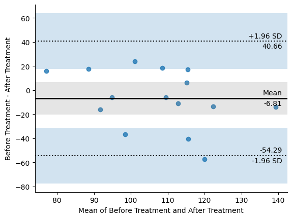

```python
from pingouin import plot_blandaltman

df = pd.DataFrame({'Before Treatment': [91.3, 107.3, 118.2, 132.3, 115.6, 97.4, 113, 85.1, 95.3, 106.6, 80.2, 91.9, 83.7, 117.8, 123.9],
                    'After Treatment': [148.8, 118.2, 112.2, 146.3, 129.2, 79.7, 89.3, 69.1, 135.8, 112.4, 116.8, 97.9, 99.8, 99.4, 106.9]})

ax = plot_blandaltman(df['Before Treatment'], df['After Treatment'])
```

# Bartlett’s Test

This test determines if the variances in data sets equal.

```python
from scipy.stats import bartlett

A = [85, 86, 88, 75, 78, 94, 98, 79, 71, 80]
B = [91, 92, 93, 85, 87, 84, 82, 88, 95, 96]
C = [79, 78, 88, 94, 92, 85, 83, 85, 82, 81]

statistic, pvalue = bartlett(A, B, C)
if pvalue >= 0.05:
    print("There is no significant difference between the variances.")
else:
    print("There is a significant difference between the variances.")
print("The statistic is: " + str(statistic) + ", the p-value is: " + str(pvalue))
```

```
There is no significant difference between the variances.
The statistic is: 3.3024375753550594, the p-value is: 0.19181598314035977
```

# Chi-Square (goodness of fit)

The chi-square goodness of fit test assesses the differences between the observed and expected proportions.

```python
from scipy.stats import chisquare

observed_data = [8, 6, 10, 7, 8, 11, 9]
expected_data = [9, 8, 11, 8, 10, 7, 6]

statistic, pvalue = chisquare(observed_data, expected_data)
if pvalue >= 0.05:
    print("There is no significant difference the observed and expected data.")
else:
    print("There is a significant difference the observed and expected data.")
print("The statistic is: " + str(statistic) + ", the p-value is: " + str(pvalue))
```

```
There is no significant difference the observed and expected data.
The statistic is: 5.0127344877344875, the p-value is: 0.542180861413329
```

# Cohen's Kappa

This test determines the level of agreement between two raters/judges who each classify items into categories. To determine the level agreement between more than two rates/judges, use **Fleiss' Kappa**.

```python
from sklearn.metrics import cohen_kappa_score

rater1 = ["negative", "positive", "negative", "neutral", "positive", "negative", "neutral", "positive"]
rater2 = ["positive", "positive", "negative", "neutral", "neutral", "negative", "neutral", "positive"]

kappa = cohen_kappa_score(rater1, rater2)
print("Cohen's Kappa score:", kappa)

if kappa < 0.1:
    print("No agreement.")
elif kappa < 0.2:
    print("Slight agreement.")
elif kappa < 0.4:
    print("Fair agreement.")
elif kappa < 0.6:
    print("Moderate agreement.")
elif kappa < 0.8:
    print("Substantial agreement.")
elif kappa < 0.99:
    print("Near perfect agreement.")
else:
    print("Perfect agreement.")
```

```
Cohen's Kappa score: 0.627906976744186
Substantial agreement.
```

# D'Agostino's K-squared Test

This test determines if a data set is normally distributed.

```python
from scipy.stats import normaltest

normally_distibuted_data = np.random.normal(size=1000)

statistic, pvalue = normaltest(normally_distibuted_data)

if pvalue >= 0.05:
 print('Data follows normal distribution.')
else:
 print('Data does not follow normal distribution.')
print("The statistic is: "  + str(statistic) + ", the p-value is: " + str(pvalue))
```

```
Data follows normal distribution.
The statistic is: 0.15635134346516635, the p-value is: 0.9248019507117738
```

# Fisher's Test

This test is used to determine if there is a significant association between two categorical variables in a 2x2 contingency table.

```python
from scipy.stats import fisher_exact

# Vaccine (experiment) group
exp_infected = 8
exp_uninfected = 92

# Placebo (control) group
ctrl_infected = 19
ctrl_uninfected = 81

result = fisher_exact(
    [[exp_infected, ctrl_infected],
    [exp_uninfected, ctrl_uninfected]]
    )

if result[1] >= 0.05:
    print("There is no significant difference between the groups.")
else:
    print("There is a significant difference between the groups.")
print("The statistic is: " + str(round(result[0],3)) + ", the p-value is: " + str(round(result[1],3)))
```

```
There is a significant difference between the groups.
The statistic is: 0.371, the p-value is: 0.037
```

# Friedman Test

Friedman's test is a nonparametric test that compares three or more paired groups.

```python
from scipy.stats import friedmanchisquare

measure1 = [4, 6, 3, 4, 3, 2, 2, 7, 6, 5]
measure2 = [5, 6, 8, 5, 7, 8, 4, 6, 4, 5]
measure3 = [2, 4, 4, 3, 2, 2, 2, 4, 3, 2]

statistic, pvalue = friedmanchisquare(measure1, measure2, measure3)
if pvalue >= 0.05:
    print("There is no significant difference between the measures.")
else:
    print("There is a significant difference between the measures.")
print("The statistic is: " + str(statistic) + ", the p-value is: " + str(pvalue))
```

```
There is a significant difference between the measures.
The statistic is: 12.666666666666673, the p-value is: 0.0017761035457343726
```

# Kendall's Tau Correlation

Kendall's Tau is a non-parametric measure of relationships between columns of ranked data.

```python
from scipy.stats import kendalltau

data = {
    'candidate': ['A', 'B', 'C', 'D', 'E', 'F', 'G', 'H', 'I', 'J', 'K', 'L'],
    'ranker1': [1, 2, 3, 4, 5, 6, 7, 8, 9, 10, 11, 12],
    'ranker2': [3, 2, 6, 4, 1, 5, 8, 7, 10, 12, 9, 11 ]
}
df = pd.DataFrame(data)


statistic, pvalue = kendalltau(df['ranker1'], df['ranker2'])
if pvalue > 0.05:
    print('There is not a relationship between the two rankers.')
else:
    print('There is a relationship between the two rankers.')
print("The statistic is: " + str(statistic) + ", the p-value is: " + str(pvalue))
```

```
There is a relationship between the two rankers.
The statistic is: 0.6666666666666666, the p-value is: 0.0018032758136924804
```

# Kolmogorov-Smirnov Tests

## Test of normality

This test determines if data is normally distributed.

```python
from scipy.stats import kstest

data = random.sample(range(0, 99), 80) # assign 80 random (not normally distributed) to list

statistic, pvalue = kstest(data, 'norm')
if pvalue > 0.05:
    print("Data is likely normally distributed.")
else:
    print("Data unlikely to be normally distributed.")
print("The statistic is: " + str(statistic) + ", the p-value is: " + str(pvalue))
```

```
Data unlikely to be normally distributed
The statistic is: 0.9611501019683699, the p-value is: 2.832830934160511e-113
```

## Two sample test

This test determines whether two samples come from the same distribution.

```python
from scipy.stats import ks_2samp

data1 = np.random.normal(100, 10, 500)  # mean, std. dev., size (samples)
data2 = np.random.normal(100, 13, 500)  # mean, std. dev., size (samples)

statistic, pvalue = ks_2samp(data1, data2)
if pvalue < 0.05:
    print("The sample distributions are different (reject null hypothesis)")
else:
    print("The sample distributions are the same (do not reject null hypothesis)")
print("The statistic is: " + str(statistic) + ", the p-value is: " + str(pvalue))
```

```
The sample distributions are different (reject null hypothesis)
The statistic is: 0.088, the p-value is: 0.04158607858587287
```